# Explaining the lack of rigor for non-standard FDR control methods

Aaron Lun

2018-12-27

# 1 Background

There are a variety of methods to control the region-level FDR in *csaw*:

- The recommended approach with `combineTests()`, using the Benjamini-Hochberg method on region-level p-values from the Simes’ method.
- Using `clusterWindows()` to control the cluster-level FDR *post hoc*, by clustering windows detected as being significant at a window-level FDR.
- Using `empiricalFDR()` to control the cluster-level FDR *post hoc*, by comparing windows with differing signs of log-fold change.

This document details some of the deficiencies of the alternative methods, which motivates preference for `combineTests()`.

# 2 Issues with `clusterWindows()`

In this function, we calculate an upper bound on the number of false positive windows. This is done based on the total number of detected windows at a particular window-level FDR threshold. An upper bound on the number of false positive clusters is computed by filling up as many clusters with false positive windows (starting from the smallest clusters). Division by the total number of clusters yields an upper bound on the cluster-level FDR.

This involves a number of approximations:

- Let $t_w$ be the window-level FDR threshold, and let the total number of windows be $N_w$. The upper bound on the expected number of false positive windows is approximated with $E(N_wt_w)$. This may not be a good approximation, with the most obvious case being when there are no true positives at all. In such cases, the expected number of false posiive windows should simply be $E(N_w)$ (the BH method only ensures that there is $t_w$ chance of non-zero $N_w$).
- Let $\tilde F_c$ be the (approximate upper bound of the) expected number of false positive clusters. Let $T_c$ be the total observed number of clusters, and let $F_c$ be the unknown total number of false positive clusters where $E(F_c) \approx \tilde F_c$. The expected FDR is defined as $E(F_c/T_c)$ (putting aside the case where $T_c=0$, for simplicity), and we are approximating this with $E(\tilde F_c/T_c)$.

Most of these approximations are okay if we obtain a precise upper bound on the number of false positive windows. A precise estimate means that the expected and observed values can be treated as interchangeable without many side effects. However, if the number of detected windows is low and/or they are correlated, sampling stochasticity will affect the precision of the upper bound. This means that the expected cluster-level FDR may not be controlled below the specified threshold.

# 3 Issues with `empiricalFDR()`

Here, the number of false positives is estimated from the number of rejections in the wrong direction. This exploits the fact that the sign is independent of significance under the equality null, such that the distribution of p-values in each direction should be equal. Thus, at any given threshold, the number of rejections in the wrong direction should be the same as the number of rejections (false positives) in the right direction.

However, restricting ourselves to the equality null is not sufficient in cases where `empiricalFDR()` is actually used. We want to avoid for non-interesting differences in binding where the statistical null hypothesis is rejected. This means that we need to consider the independence of the p-value and sign under arbitary alternative hypotheses. Unfortunately, the p-value distribution from the likelihood ratio test is not independent of the sign under arbitrary (but symmetric) null hypotheses. Consider the following example with 4-fold up- or down-regulation, involving libraries of different size between groups:

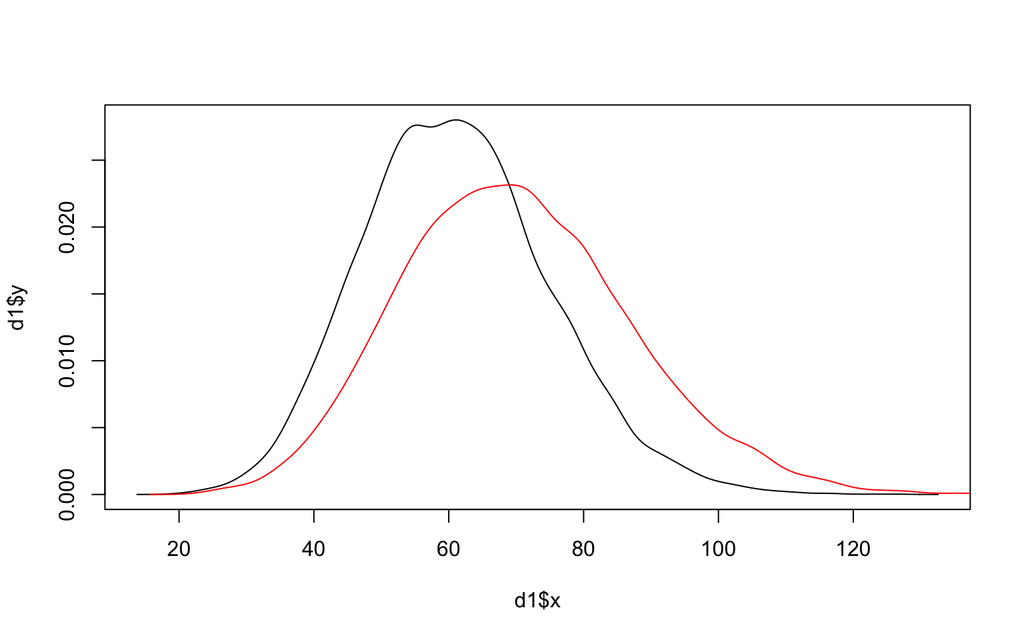

```r
library(edgeR)

design <- model.matrix(~gl(2, 5))
y1 <- matrix(rpois(100000, lambda=rep(c(5, 40), each=5)), byrow=TRUE, ncol=nrow(design)) # 4-fold change in larger library.
fit1 <- glmFit(y1, design, dispersion=0, offset=log(rep(1:2, each=5)))
res1 <- glmLRT(fit1)

y2 <- matrix(rpois(100000, lambda=rep(c(20, 10), each=5)), byrow=TRUE, ncol=nrow(design)) # 4-fold change in smaller library.
fit2 <- glmFit(y2, design, dispersion=0, offset=log(rep(1:2, each=5)))
res2 <- glmLRT(fit2)

d1 <- density(res1$table$LR)
d2 <- density(res2$table$LR)
plot(d1$x, d1$y, xlim=range(d1$x), type="l")
lines(d2$x, d2$y, col="red")
```

… or involving a different number of libraries between groups:

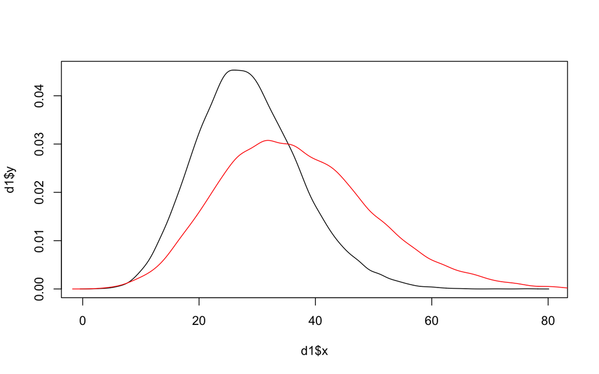

```r
library(edgeR)

design <- model.matrix(~factor(c(1,2,2,2,2)))
y1 <- matrix(rpois(100000, lambda=c(10,40,40,40,40)), byrow=TRUE, ncol=nrow(design)) # 4-fold change in larger group.
fit1 <- glmFit(y1, design, dispersion=0, offset=numeric(nrow(design)))
res1 <- glmLRT(fit1)

y2 <- matrix(rpois(100000, lambda=c(40,10,10,10,10)), byrow=TRUE, ncol=nrow(design)) # 4-fold change in smaller group.
fit2 <- glmFit(y2, design, dispersion=0, offset=numeric(nrow(design)))
res2 <- glmLRT(fit2)

d1 <- density(res1$table$LR)
d2 <- density(res2$table$LR)
plot(d1$x, d1$y, xlim=range(d1$x), type="l")
lines(d2$x, d2$y, col="red")
```

This is highly relevant as many experiments will not have the same number of control libraries as ChIP libraries, mostly as a cost-saving measure. Asymmetric p-value distributions can reduce the estimated number of false positives and lead to underestimation of the empirical FDR:

```r
right <- c(rep(0, 100), runif(1000)) # 100 true positives, 1000 false positives.
wrong <- rbeta(1000, 2, 1) # 1000 false positives, but not the same as above.
emp <- findInterval(right, sort(wrong))/rank(right)
o <- order(right, decreasing=TRUE)
emp[o] <- cummin(emp[o])
sum(which(emp<=0.05)>100)/sum(emp <= 0.05)
```

```
## [1] 0.4565217
```

In contrast, the BH method would be able to control the FDR correctly, provided that the p-value distribution is uniform or right-skewed. This is because it accounts for the absolute size of the $p$-values, rather than their size relative to other $p$-values (i.e., those changing in the wrong direction).

```r
bh <- p.adjust(right, method="BH")
sum(which(bh<=0.05)>100)/sum(bh <= 0.05)
```

```
## [1] 0.06542056
```

There are also some further miscellaneous issues:

- Even if we ignore the issues with statistical power, we must also consider experimental artifacts that bias rejections in one direction or another. This is possible if the negative control does not capture the same type of false positives that are present in the ChIP sample. Input controls are especially troublesome in this regard.
- The set of p-values in the wrong direction is not completely representative of false positive regions. It includes p-values from regions with one or more true positive windows, which should not be considered false positives, even if they contain false positive windows. This results in some conservativeness as the number of false positives at any given threshold is overestimated. There’s no obvious way to avoid this, as you’d need to know which regions were true positives to prune them out of the set.
- The estimate of the empirical FDR will not be precise if there are not many rejections, especially at low $p$-value thresholds.

# 4 Wrapping up

```
## R Under development (unstable) (2018-12-07 r75787)
## Platform: x86_64-apple-darwin15.6.0 (64-bit)
## Running under: OS X El Capitan 10.11.6
##
## Matrix products: default
## BLAS: /Library/Frameworks/R.framework/Versions/3.6/Resources/lib/libRblas.0.dylib
## LAPACK: /Library/Frameworks/R.framework/Versions/3.6/Resources/lib/libRlapack.dylib
##
## locale:
## [1] en_GB.UTF-8/en_GB.UTF-8/en_GB.UTF-8/C/en_GB.UTF-8/en_GB.UTF-8
##
## attached base packages:
## [1] stats     graphics  grDevices utils     datasets  methods   base
##
## other attached packages:
## [1] edgeR_3.25.2     limma_3.39.3     BiocStyle_2.11.0
##
## loaded via a namespace (and not attached):
##  [1] locfit_1.5-9.1     Rcpp_1.0.0         bookdown_0.9
##  [4] lattice_0.20-38    digest_0.6.18      grid_3.6.0
##  [7] magrittr_1.5       evaluate_0.12      stringi_1.2.4
## [10] rmarkdown_1.11     tools_3.6.0        stringr_1.3.1
## [13] xfun_0.4           yaml_2.2.0         compiler_3.6.0
## [16] BiocManager_1.30.4 htmltools_0.3.6    knitr_1.21
```